# (Exploratory Data Analysis: Loan Data from Prosper)

## Introduction

This is Exploratory Data Analysis (EDA) on a data set from Prosper, which is America’s first peer-to-peer, or marketplace, lending platform, with over $9 billion in funded loans. This data set contains 113,937 loans with 81 variables on each loan, including loan amount, borrower rate (or interest rate), current loan status, borrower income, borrower employment status, borrower credit history, and the latest payment information.

This [data dictionary](https://docs.google.com/spreadsheets/d/1gDyi_L4UvIrLTEC6Wri5nbaMmkGmLQBk-Yx3z0XDEtI/edit#gid=0) explains the variables in the data set.

The main purposes of this project are to summarize the characteristics of variables that can affect the loan status and to get some ideas about the relationships among multiple variables using data visualizations.

The outline of this project is:

- Introduction
- Univariate Exploration
- Bivariate Exploration
- Multivariate Exploration

```python
# import all packages and set plots to be embedded inline
import numpy as np
import pandas as pd
import matplotlib.pyplot as plt
import seaborn as sb

%matplotlib inline
```

### Load dataset using pandas

```python
df = pd.read_csv('prosperLoanData.csv')
```

```python
df.head()
```

|  | ListingKey | ListingNumber | ListingCreationDate | CreditGrade | Term | LoanStatus | ClosedDate | BorrowerAPR | BorrowerRate | LenderYield | EstimatedEffectiveYield | EstimatedLoss | EstimatedReturn | ProsperRating (numeric) | ProsperRating (Alpha) | ProsperScore | ListingCategory (numeric) | BorrowerState | Occupation | EmploymentStatus | EmploymentStatusDuration | IsBorrowerHomeowner | CurrentlyInGroup | GroupKey | DateCreditPulled | CreditScoreRangeLower | CreditScoreRangeUpper | FirstRecordedCreditLine | CurrentCreditLines | … |
| --- | --- | --- | --- | --- | --- | --- | --- | --- | --- | --- | --- | --- | --- | --- | --- | --- | --- | --- | --- | --- | --- | --- | --- | --- | --- | --- | --- | --- | --- | --- |
| 0 | 1021339766868145413AB3B | 193129 | 2007-08-26 19:09:29.263000000 | C | 36 | Completed | 2009-08-14 00:00:00 | 0.16516 | 0.1580 | 0.1380 | NaN | NaN | NaN | NaN | NaN | NaN | 0 | CO | Other | Self-employed | 2.0 | True | True | NaN | 2007-08-26 18:41:46.780000000 | 640.0 | 659.0 | 2001-10-11 00:00:00 | 5.0 | … |
| 1 | 10273602499503308B223C1 | 1209647 | 2014-02-27 08:28:07.900000000 | NaN | 36 | Current | NaN | 0.12016 | 0.0920 | 0.0820 | 0.07960 | 0.0249 | 0.05470 | 6.0 | A | 7.0 | 2 | CO | Professional | Employed | 44.0 | False | False | NaN | 2014-02-27 08:28:14 | 680.0 | 699.0 | 1996-03-18 00:00:00 | 14.0 | … |
| 2 | 0EE9337825851032864889A | 81716 | 2007-01-05 15:00:47.090000000 | HR | 36 | Completed | 2009-12-17 00:00:00 | 0.28269 | 0.2750 | 0.2400 | NaN | NaN | NaN | NaN | NaN | NaN | 0 | GA | Other | Not available | NaN | False | True | 783C3371218786870A73D20 | 2007-01-02 14:09:10.060000000 | 480.0 | 499.0 | 2002-07-27 00:00:00 | NaN | … |
| 3 | 0EF5356002482715299901A | 658116 | 2012-10-22 11:02:35.010000000 | NaN | 36 | Current | NaN | 0.12528 | 0.0974 | 0.0874 | 0.08490 | 0.0249 | 0.06000 | 6.0 | A | 9.0 | 16 | GA | Skilled Labor | Employed | 113.0 | True | False | NaN | 2012-10-22 11:02:32 | 800.0 | 819.0 | 1983-02-28 00:00:00 | 5.0 | … |
| 4 | 0F023589499656230C5E3E2 | 909464 | 2013-09-14 18:38:39.097000000 | NaN | 36 | Current | NaN | 0.24614 | 0.2085 | 0.1985 | 0.18316 | 0.0925 | 0.09066 | 3.0 | D | 4.0 | 2 | MN | Executive | Employed | 44.0 | True | False | NaN | 2013-09-14 18:38:44 | 680.0 | 699.0 | 2004-02-20 00:00:00 | 19.0 | … |

### Structure of dataset

```python
print('Number of rows: ', df.shape[0])
print('Number of columns: ', df.shape[1])
```

```
Number of rows:  113937
Number of columns:  81
```

### Main feature(s) of interest in the dataset

I'm most interested in understanding about how peer-to-peer, or marketplace lending works for Prosper. Two questions deserve our attention which are as mentioned below:

- What risk factors does Prosper consider before granting loans?
- What are the trends in returns for the granted loans by Prosper?

### Features in the dataset I think will help support investigation into feature(s) of interest

```python
df.head()
```

|  | ListingKey | ListingNumber | ListingCreationDate | CreditGrade | Term | LoanStatus | ClosedDate | BorrowerAPR | BorrowerRate | LenderYield | EstimatedEffectiveYield | EstimatedLoss | EstimatedReturn | ProsperRating (numeric) | ProsperRating (Alpha) | ProsperScore | ListingCategory (numeric) | BorrowerState | Occupation | EmploymentStatus | EmploymentStatusDuration | IsBorrowerHomeowner | CurrentlyInGroup | GroupKey | DateCreditPulled | CreditScoreRangeLower | CreditScoreRangeUpper | FirstRecordedCreditLine | CurrentCreditLines | … |
| --- | --- | --- | --- | --- | --- | --- | --- | --- | --- | --- | --- | --- | --- | --- | --- | --- | --- | --- | --- | --- | --- | --- | --- | --- | --- | --- | --- | --- | --- | --- |
| 0 | 1021339766868145413AB3B | 193129 | 2007-08-26 19:09:29.263000000 | C | 36 | Completed | 2009-08-14 00:00:00 | 0.16516 | 0.1580 | 0.1380 | NaN | NaN | NaN | NaN | NaN | NaN | 0 | CO | Other | Self-employed | 2.0 | True | True | NaN | 2007-08-26 18:41:46.780000000 | 640.0 | 659.0 | 2001-10-11 00:00:00 | 5.0 | … |
| 1 | 10273602499503308B223C1 | 1209647 | 2014-02-27 08:28:07.900000000 | NaN | 36 | Current | NaN | 0.12016 | 0.0920 | 0.0820 | 0.07960 | 0.0249 | 0.05470 | 6.0 | A | 7.0 | 2 | CO | Professional | Employed | 44.0 | False | False | NaN | 2014-02-27 08:28:14 | 680.0 | 699.0 | 1996-03-18 00:00:00 | 14.0 | … |
| 2 | 0EE9337825851032864889A | 81716 | 2007-01-05 15:00:47.090000000 | HR | 36 | Completed | 2009-12-17 00:00:00 | 0.28269 | 0.2750 | 0.2400 | NaN | NaN | NaN | NaN | NaN | NaN | 0 | GA | Other | Not available | NaN | False | True | 783C3371218786870A73D20 | 2007-01-02 14:09:10.060000000 | 480.0 | 499.0 | 2002-07-27 00:00:00 | NaN | … |
| 3 | 0EF5356002482715299901A | 658116 | 2012-10-22 11:02:35.010000000 | NaN | 36 | Current | NaN | 0.12528 | 0.0974 | 0.0874 | 0.08490 | 0.0249 | 0.06000 | 6.0 | A | 9.0 | 16 | GA | Skilled Labor | Employed | 113.0 | True | False | NaN | 2012-10-22 11:02:32 | 800.0 | 819.0 | 1983-02-28 00:00:00 | 5.0 | … |
| 4 | 0F023589499656230C5E3E2 | 909464 | 2013-09-14 18:38:39.097000000 | NaN | 36 | Current | NaN | 0.24614 | 0.2085 | 0.1985 | 0.18316 | 0.0925 | 0.09066 | 3.0 | D | 4.0 | 2 | MN | Executive | Employed | 44.0 | True | False | NaN | 2013-09-14 18:38:44 | 680.0 | 699.0 | 2004-02-20 00:00:00 | 19.0 | … |

```python
pd.set_option("display.max_columns", len(df.columns))
df.head()
```

|  | ListingKey | ListingNumber | ListingCreationDate | CreditGrade | Term | LoanStatus | ClosedDate | BorrowerAPR | BorrowerRate | LenderYield | EstimatedEffectiveYield | EstimatedLoss | EstimatedReturn | ProsperRating (numeric) | ProsperRating (Alpha) | ProsperScore | ListingCategory (numeric) | BorrowerState | Occupation | EmploymentStatus | EmploymentStatusDuration | IsBorrowerHomeowner | CurrentlyInGroup | GroupKey | DateCreditPulled | CreditScoreRangeLower | CreditScoreRangeUpper | FirstRecordedCreditLine | CurrentCreditLines | … |
| --- | --- | --- | --- | --- | --- | --- | --- | --- | --- | --- | --- | --- | --- | --- | --- | --- | --- | --- | --- | --- | --- | --- | --- | --- | --- | --- | --- | --- | --- | --- |
| 0 | 1021339766868145413AB3B | 193129 | 2007-08-26 19:09:29.263000000 | C | 36 | Completed | 2009-08-14 00:00:00 | 0.16516 | 0.1580 | 0.1380 | NaN | NaN | NaN | NaN | NaN | NaN | 0 | CO | Other | Self-employed | 2.0 | True | True | NaN | 2007-08-26 18:41:46.780000000 | 640.0 | 659.0 | 2001-10-11 00:00:00 | 5.0 | … |
| 1 | 10273602499503308B223C1 | 1209647 | 2014-02-27 08:28:07.900000000 | NaN | 36 | Current | NaN | 0.12016 | 0.0920 | 0.0820 | 0.07960 | 0.0249 | 0.05470 | 6.0 | A | 7.0 | 2 | CO | Professional | Employed | 44.0 | False | False | NaN | 2014-02-27 08:28:14 | 680.0 | 699.0 | 1996-03-18 00:00:00 | 14.0 | … |
| 2 | 0EE9337825851032864889A | 81716 | 2007-01-05 15:00:47.090000000 | HR | 36 | Completed | 2009-12-17 00:00:00 | 0.28269 | 0.2750 | 0.2400 | NaN | NaN | NaN | NaN | NaN | NaN | 0 | GA | Other | Not available | NaN | False | True | 783C3371218786870A73D20 | 2007-01-02 14:09:10.060000000 | 480.0 | 499.0 | 2002-07-27 00:00:00 | NaN | … |
| 3 | 0EF5356002482715299901A | 658116 | 2012-10-22 11:02:35.010000000 | NaN | 36 | Current | NaN | 0.12528 | 0.0974 | 0.0874 | 0.08490 | 0.0249 | 0.06000 | 6.0 | A | 9.0 | 16 | GA | Skilled Labor | Employed | 113.0 | True | False | NaN | 2012-10-22 11:02:32 | 800.0 | 819.0 | 1983-02-28 00:00:00 | 5.0 | … |
| 4 | 0F023589499656230C5E3E2 | 909464 | 2013-09-14 18:38:39.097000000 | NaN | 36 | Current | NaN | 0.24614 | 0.2085 | 0.1985 | 0.18316 | 0.0925 | 0.09066 | 3.0 | D | 4.0 | 2 | MN | Executive | Employed | 44.0 | True | False | NaN | 2013-09-14 18:38:44 | 680.0 | 699.0 | 2004-02-20 00:00:00 | 19.0 | … |

The main features of the dataset that will help support investigation into feature(s) of interest:

- CreditGrade: The Credit rating that was assigned at the time the listing went live
- Term: The length of the loan expressed in months
- LoanStatus: The current status of the loan: Cancelled, Chargedoff, Completed, Current, Defaulted, FinalPaymentInProgress, PastDue
- ClosedDate: Closed date is applicable for Cancelled, Completed, Chargedoff and Defaulted loan statuses
- BorrowerAPR: The Borrower's Annual Percentage Rate (APR) for the loan
- BorrowerRate: The Borrower's interest rate for this loan
- EstimatedLoss: Estimated loss is the estimated principal loss on charge-offs.
- ProsperScore: A custom risk score built using historical Prosper data. The score ranges from 1-10, with 10 being the best, or lowest risk score
- ProsperRating (numeric): The Prosper Rating assigned at the time the listing was created: 0 - N/A, 1 - HR, 2 - E, 3 - D, 4 - C, 5 - B, 6 - A, 7 - AA.
- ListingCategory (numeric): The category of the listing that the borrower selected when posting their listing: 0 - Not Available, 1 - Debt Consolidation, 2 - Home Improvement, 3 - Business, 4 - Personal Loan, 5 - Student Use, 6 - Auto, 7- Other, 8 - Baby&Adoption, 9 - Boat, 10 - Cosmetic Procedure, 11 - Engagement Ring, 12 - Green Loans, 13 - Household Expenses, 14 - Large Purchases, 15 - Medical/Dental, 16 - Motorcycle, 17 - RV, 18 - Taxes, 19 - Vacation, 20 - Wedding Loans
- Occupation: The Occupation selected by the Borrower at the time they created the listing
- IsBorrowerHomeowner: A Borrower will be classified as a homowner if they have a mortgage on their credit profile or provide documentation confirming they are a homeowner
- DebtToIncomeRatio: The debt to income ratio of the borrower at the time the credit profile was pulled. This value is Null if the debt to income ratio is not available. This value is capped at 10.01 (any debt to income ratio larger than 1000% will be returned as 1001%)
- IsBorrowerHomeowner: A Borrower will be classified as a homowner if they have a mortgage on their credit profile or provide documentation confirming they are a homeowner.
- AvailableBankcardCredit: The total available credit via bank card at the time the credit profile was pulled.
- StatedMonthlyIncome: The monthly income the borrower stated at the time the listing was created
- MonthlyLoanPayment: The scheduled monthly loan payment
- LoanOriginalAmount: The origination amount of the loan
- LoanOriginationDate: The date the loan was originated

## Univariate Exploration

In this section, we will investigate distributions of individual variables. If we see unusual points or outliers, we will take a deeper look to clean things up and prepare ourselves to look at relationships between variables.

### Explore the distribution of month derived from 'LoanOriginationDate' feature

It would be interesting to find whether the number of loans taken increased or decreased during specific months.

```python
# Check data type
df['LoanOriginationDate'].dtype
```

```
dtype('O')
```

```python
# Check for null values
df['LoanOriginationDate'].isnull().any()
```

```
False
```

```python
# Change data type to datetime
df['LoanOriginationDate'] = pd.to_datetime(df['LoanOriginationDate'])
```

```python
# Verify the change
df['LoanOriginationDate'].head()
```

```
0   2007-09-12
1   2014-03-03
2   2007-01-17
3   2012-11-01
4   2013-09-20
Name: LoanOriginationDate, dtype: datetime64[ns]
```

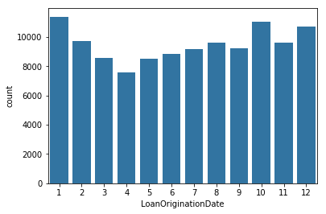

```python
# Bar chart for distribution of month derived from 'LoanOriginationDate' feature
default_color = sb.color_palette()[0]
sb.countplot(data=df, x=df['LoanOriginationDate'].dt.month, color=default_color);
```

We find that the amount of loans granted by Prosper have usually risen at the start and end of the year for the months January, February, October, November and December.

### Explore the distribution of month derived from 'ClosedDate' feature

If the number of loans taken have risen in a specific period, it would not be uncommon to see the rise in loans defaulted during the same periods as well. Let's verify this assumption.

```python
# Check data type
df['ClosedDate'].dtype
```

```
dtype('O')
```

```python
# Check for null values
df['LoanOriginationDate'].isnull().any()
```

```
False
```

```python
# Change data type to datetime
df['ClosedDate'] = pd.to_datetime(df['ClosedDate'])
```

```python
# Verify the change
df['ClosedDate'].head()
```

```
0   2009-08-14
1          NaT
2   2009-12-17
3          NaT
4          NaT
Name: ClosedDate, dtype: datetime64[ns]
```

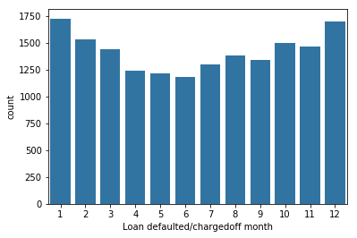

```python
# Bar chart for distribution of month derived from 'LoanOriginationDate' feature
sb.countplot(data=df, \
             x=df[(df['LoanStatus'] == 'Defaulted') | (df['LoanStatus'] == 'Chargedoff')]['ClosedDate'].dt.month, \
             color=default_color)
plt.xlabel('Loan defaulted/chargedoff month');
```

Loans taken have shown to rise at the start and end of the year for the months January, February, October, November and December, and so does the loan defaulted/charged off month as the respective plots come out to be similar.

### Explore and compare the distributions for BorrowerAPR and BorrowerRate

What is the difference between BorrowerAPR and BorrowerRate?

When calculating the cost of debt, BorrowerRate (interest rate) indicates the percentage charged for borrowing money over a given period of time, while annual percentage rate (APR) takes into account yearly interest plus other upfront or recurring loan fees.

- The interest rate does not include fees charged for the loan
- Unlike an interest rate, it includes other charges or fees (such as mortgage insurance, most closing costs, discount points and loan origination fees) to reflect the total cost of the loan

```python
df.BorrowerAPR.describe()
```

```
count    113912.000000
mean          0.218828
std           0.080364
min           0.006530
25%           0.156290
50%           0.209760
75%           0.283810
max           0.512290
Name: BorrowerAPR, dtype: float64
```

```python
df.BorrowerRate.describe()
```

```
count    113937.000000
mean          0.192764
std           0.074818
min           0.000000
25%           0.134000
50%           0.184000
75%           0.250000
max           0.497500
Name: BorrowerRate, dtype: float64
```

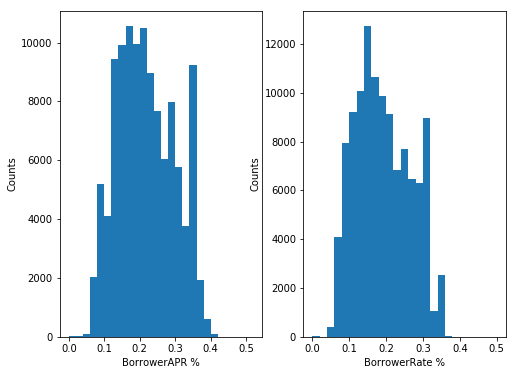

```python
# Bar charts for distributions for BorrowerAPR and BorrowerRate respectively
plt.figure(figsize = [8, 6])

plt.subplot(1, 2, 1)
bin_size = 0.02
bin_edges = np.arange(0, df['BorrowerAPR'].max()+bin_size, bin_size)
plt.hist(data=df, x='BorrowerAPR', bins=bin_edges)
plt.xlabel('BorrowerAPR %')
plt.ylabel('Counts')

plt.subplot(1, 2, 2)
bin_size = 0.02
bin_edges = np.arange(0, df['BorrowerRate'].max()+bin_size, bin_size)
plt.hist(data=df, x='BorrowerRate', bins=bin_edges)
plt.xlabel('BorrowerRate %')
plt.ylabel('Counts');
```

Distribution of BorrowerAPR and BorrowerRate seem to be similar with APR rate being higher than the interest rate which makes sense as interest rate does not include fees charged for the loan and other charges.

```python
# Check data type
df['ProsperScore'].dtype
```

```
dtype('float64')
```

```python
df['ProsperScore'].value_counts()
```

```
4.0     12595
6.0     12278
8.0     12053
7.0     10597
5.0      9813
3.0      7642
9.0      6911
2.0      5766
10.0     4750
11.0     1456
1.0       992
Name: ProsperScore, dtype: int64
```

```python
df['ProsperScore'] = df['ProsperScore'].fillna(0)
```

```python
# Convert 'ProsperScore' feature values to integer type
df['ProsperScore'] = df['ProsperScore'].apply(lambda x: int(x))
```

```python
# Check the change
df['ProsperScore'].value_counts()
```

```
0     29084
4     12595
6     12278
8     12053
7     10597
5      9813
3      7642
9      6911
2      5766
10     4750
11     1456
1       992
Name: ProsperScore, dtype: int64
```

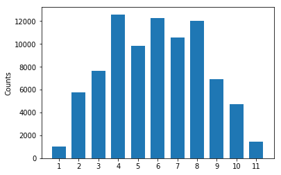

```python
# Bar chart for 'ProsperScore' feature
bin_edges = np.arange(0.5, 11.5+1, 1)
plt.hist(df['ProsperScore'], bins=bin_edges, rwidth = 0.7)
plt.xticks(np.arange(1, 11+1, 1), [1, 2, 3, 4, 5, 6, 7, 8, 9, 10, 11])
plt.ylabel('Counts');
```

### Explore distribution of 'StatedMonthlyIncome' feature

```python
# Check data type
df['StatedMonthlyIncome'].dtype
```

```
dtype('float64')
```

```python
# Check for any null values
df['StatedMonthlyIncome'].isnull().any()
```

```
False
```

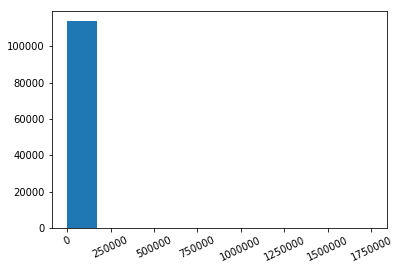

```python
# Histogram for distribution of 'StatedMonthlyIncome' feature
plt.hist(data=df, x='StatedMonthlyIncome')
plt.xticks(rotation=25);
```

The histogram is highly skewed to the right. To find the outliers we can use the describe() and sort_values() function. We need to remove the outliers.

```python
df['StatedMonthlyIncome'].describe()
```

```
count    1.139370e+05
mean     5.608026e+03
std      7.478497e+03
min      0.000000e+00
25%      3.200333e+03
50%      4.666667e+03
75%      6.825000e+03
max      1.750003e+06
Name: StatedMonthlyIncome, dtype: float64
```

```python
# Sorted series in descending order for the column 'StatedMonthlyIncome'
sorted_monthly_income = df.sort_values(['StatedMonthlyIncome'], ascending=False)['StatedMonthlyIncome']
sorted_monthly_income
```

```
53167     1.750003e+06
53014     6.185478e+05
17411     4.833333e+05
57133     4.666667e+05
8066      4.166667e+05
113270    3.944000e+05
82831     2.500000e+05
8870      2.083333e+05
56867     1.850818e+05
83697     1.850818e+05
80075     1.583333e+05
45028     1.500000e+05
63925     1.404167e+05
59298     1.208333e+05
111265    1.087500e+05
```

[output cut: 47 more lines]

```python
sorted_monthly_income.shape
```

```
(113937,)
```

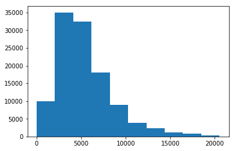

```python
# Histogram after removing outliers: removed the top one percent of the feature 'StatedMonthlyIncome'
plt.hist(data=df, \
         x=sorted_monthly_income[int(0.01 * sorted_monthly_income.shape[0]):]);
```

We find that the range of average monthly incomes of borrowers lies under USD 20000 approximately. Most frequent stated monthly incomes lie around USD 5000 approximately.

### Explore distribution of 'ListingCategory (numeric)' feature

Let's try and find out what do people mostly take loans for.

```python
# Check data type
df['ListingCategory (numeric)'].dtype
```

```
dtype('int64')
```

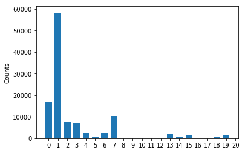

```python
# Bar chart for distribution of 'ListingCategory (numeric)' feature
bin_edges = np.arange(0, 20+1, 1)
plt.hist(df['ListingCategory (numeric)'], bins=bin_edges, rwidth = 0.7)
plt.xticks(np.arange(0.5, 20.5+1, 1), np.arange(0, 20+1, 1))
plt.ylabel('Counts');
```

```python
# Validate the bar chart above using value_counts function
df['ListingCategory (numeric)'].value_counts()
```

```
1     58308
0     16965
7     10494
2      7433
3      7189
6      2572
4      2395
13     1996
15     1522
18      885
14      876
20      771
19      768
5       756
16      304
11      217
8       199
10       91
9        85
12       59
17       52
Name: ListingCategory (numeric), dtype: int64
```

'ListingCategory (numeric)' is the category of the listing that the borrower selected when posting their listing 0 - Not Available, 1 - Debt Consolidation, 2 - Home Improvement, 3 - Business, 4 - Personal Loan, 5 - Student Use, 6 - Auto, 7- Other, 8 - Baby&Adoption, 9 - Boat, 10 - Cosmetic Procedure, 11 - Engagement Ring, 12 - Green Loans, 13 - Household Expenses, 14 - Large Purchases, 15 - Medical/Dental, 16 - Motorcycle, 17 - RV, 18 - Taxes, 19 - Vacation, 20 - Wedding Loans

Renaming the category feature and changing data type from integer to categorical.

```python
df.replace(to_replace={"ListingCategory (numeric)": {0: "NotAvailable",
                                                     1: "DebtConsolidation",
                                                     2: "HomeImprovement",
                                                     3: "Business",
                                                     4: "Personal",
                                                     5: "Student",
                                                     6: "Auto",
                                                     7: "Other",
                                                     8: "BabyAndAdoption",
                                                     9: "Boat",
                                                     10: "CosmeticProcedure",
                                                     11: "Engagement",
                                                     12: "GreenLoan",
                                                     13: "Household",
                                                     14: "LargePurchases",
                                                     15: "MedicalOrDental",
                                                     16: "Motorcycle",
                                                     17: "RV",
                                                     18: "Taxes",
                                                     19: "Vacation",
                                                     20: "Wedding"}}, inplace=True)

df.rename(index=str, columns={"ListingCategory (numeric)": "ListingCategory"}, inplace=True)

df["ListingCategory"].unique()
```

```
array(['NotAvailable', 'HomeImprovement', 'Motorcycle',
       'DebtConsolidation', 'Other', 'Household', 'Auto',
       'MedicalOrDental', 'Wedding', 'Vacation', 'Business', 'Taxes',
       'BabyAndAdoption', 'Personal', 'Engagement', 'LargePurchases',
       'Student', 'Boat', 'RV', 'CosmeticProcedure', 'GreenLoan'],
      dtype=object)
```

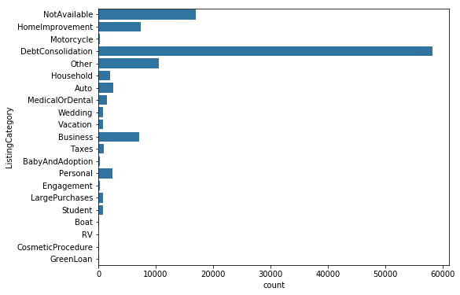

```python
# Bar chart for distribution of 'ListingCategory' feature
plt.figure(figsize = [8, 6])
sb.countplot(data=df, y=df['ListingCategory'], color=default_color);
```

We find that people mostly take loans for debt consolidation, home improvement and business.

### Explore distribution of 'MonthlyLoanPayment' feature

```python
# Check data type
df['MonthlyLoanPayment'].dtype
```

```
dtype('float64')
```

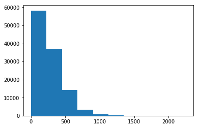

```python
# Histogram for distribution of 'MonthlyLoanPayment' feature
plt.hist(data=df, x='MonthlyLoanPayment');
```

We find that the histogram is skewed to the right and hence we will apply log transformations to get a better understanding.

```python
df['MonthlyLoanPayment'].describe()
```

```
count    113937.000000
mean        272.475783
std         192.697812
min           0.000000
25%         131.620000
50%         217.740000
75%         371.580000
max        2251.510000
Name: MonthlyLoanPayment, dtype: float64
```

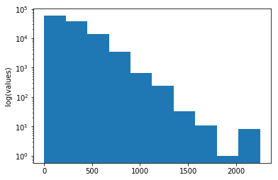

```python
# Histogram for distribution of 'MonthlyLoanPayment' feature by applying scale (log) transformation
plt.hist(df['MonthlyLoanPayment'])
plt.yscale('log')
plt.ylabel('log(values)');
```

We find that most monthly loan payment amounts fall under USD 1500 which seems to suggest that most Prosper Loans fall under the personal loan category.

### Explore distribution of 'AvailableBankcardCredit' feature

```python
# Check data type
df['AvailableBankcardCredit'].dtype
```

```
dtype('float64')
```

```python
# Descriptive summary statistics
df['AvailableBankcardCredit'].describe()
```

```
count    106393.000000
mean      11210.225447
std       19818.361309
min           0.000000
25%         880.000000
50%        4100.000000
75%       13180.000000
max      646285.000000
Name: AvailableBankcardCredit, dtype: float64
```

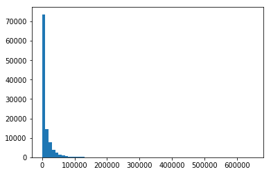

```python
# Histogram for distribution of 'AvailableBankcardCredit' feature
bin_edges = np.arange(0, df['AvailableBankcardCredit'].max()+10000, 10000)
plt.hist(df['AvailableBankcardCredit'], bins=bin_edges);
```

The plot is highly skewed to the right and hence need to apply scale transformation.

```python
# Sorted series in descending order for the column 'StatedMonthlyIncome'
sorted_available_bankcredit = df.sort_values(['AvailableBankcardCredit'], ascending=False)['AvailableBankcardCredit']
sorted_available_bankcredit
```

```
24916     646285.0
93897     572427.0
105754    566480.0
80178     498374.0
39804     477656.0
38528     463575.0
92406     432613.0
98518     413367.0
39756     413072.0
99673     412785.0
64246     406125.0
41112     403880.0
86383     403534.0
39789     400790.0
95000     400395.0
```

[output cut: 47 more lines]

```python
sorted_available_bankcredit.shape
```

```
(113937,)
```

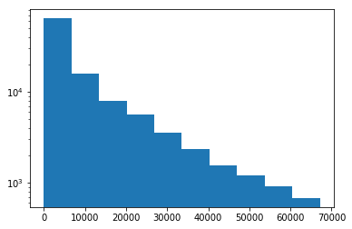

```python
# Histogram after removing the top two percent of the feature 'StatedMonthlyIncome' and applying log transformation
plt.hist(data=df, \
         x=sorted_available_bankcredit[int(0.02 * sorted_available_bankcredit.shape[0]):])
plt.yscale('log');
```

We find an increase in frequency of loans with decrease in the feature value of 'AvailableBankcardCredit'.

### Explore distribution of 'DebtToIncomeRatio' feature

```python
# Check data type
df['DebtToIncomeRatio'].dtype
```

```
dtype('float64')
```

```python
# Descriptive summary statistics
df['DebtToIncomeRatio'].describe()
```

```
count    105383.000000
mean          0.275947
std           0.551759
min           0.000000
25%           0.140000
50%           0.220000
75%           0.320000
max          10.010000
Name: DebtToIncomeRatio, dtype: float64
```

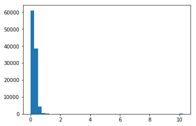

```python
# Histogram for distribution of 'DebtToIncomeRatio' feature
bin_edges = np.arange(0, df['DebtToIncomeRatio'].max()+0.25, 0.25)
plt.hist(data=df, x=df['DebtToIncomeRatio'], bins=bin_edges);
```

Histogram is highly skewed to the right. We need to apply scale transformation by removing the top one percent of the data for 'DebtToIncomeRatio' feature.

```python
# Sorted series in descending order for the column 'DebtToIncomeRatio'
sorted_debt_to_incmoe_ratio = df.sort_values(['DebtToIncomeRatio'], ascending=False)['DebtToIncomeRatio']
sorted_debt_to_incmoe_ratio
```

```
60894     10.01
59733     10.01
70843     10.01
20524     10.01
113626    10.01
84621     10.01
32383     10.01
1925      10.01
54517     10.01
18463     10.01
70679     10.01
87586     10.01
226       10.01
56897     10.01
32237     10.01
```

[output cut: 47 more lines]

```python
sorted_debt_to_incmoe_ratio.shape
```

```
(113937,)
```

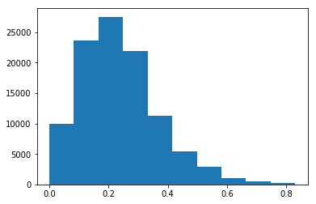

```python
# Histogram after removing outliers: removed the top one percent of the feature 'DebtToIncomeRatio'
plt.hist(data=df, \
         x=sorted_debt_to_incmoe_ratio[int(0.01 * sorted_debt_to_incmoe_ratio.shape[0]):]);
```

We find that debt to income ratio mostly lie under 0.4 which means that for most people granted loans by Prosper, less than 40 percent of their income is committed to debts.

### Explore distribution of 'CreditGrade' feature

```python
# Check data type
df['CreditGrade'].dtype
```

```
dtype('O')
```

```python
df['CreditGrade'].value_counts()
```

```
C     5649
D     5153
B     4389
AA    3509
HR    3508
A     3315
E     3289
NC     141
Name: CreditGrade, dtype: int64
```

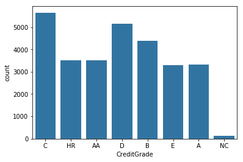

```python
# Histogram for distribution of 'CreditGrade' feature
sb.countplot(data=df, x='CreditGrade', color=default_color);
```

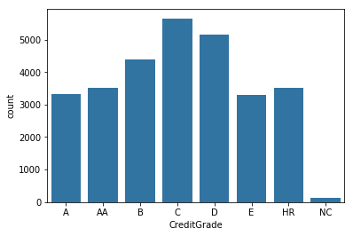

```python
level_order = ['A', 'AA', 'B', 'C', 'D', 'E', 'HR', 'NC']
ordered_cat = pd.api.types.CategoricalDtype(ordered=True, categories=level_order)
df['CreditGrade'] = df['CreditGrade'].astype(ordered_cat)
sb.countplot(data=df, x='CreditGrade', color=default_color);
```

We find that 'C' and 'D' are the most predominant 'CreditGrade' ratings.

### Explore distribution of 'Occupation' feature

```python
# Check data type
df['Occupation'].dtype
```

```
dtype('O')
```

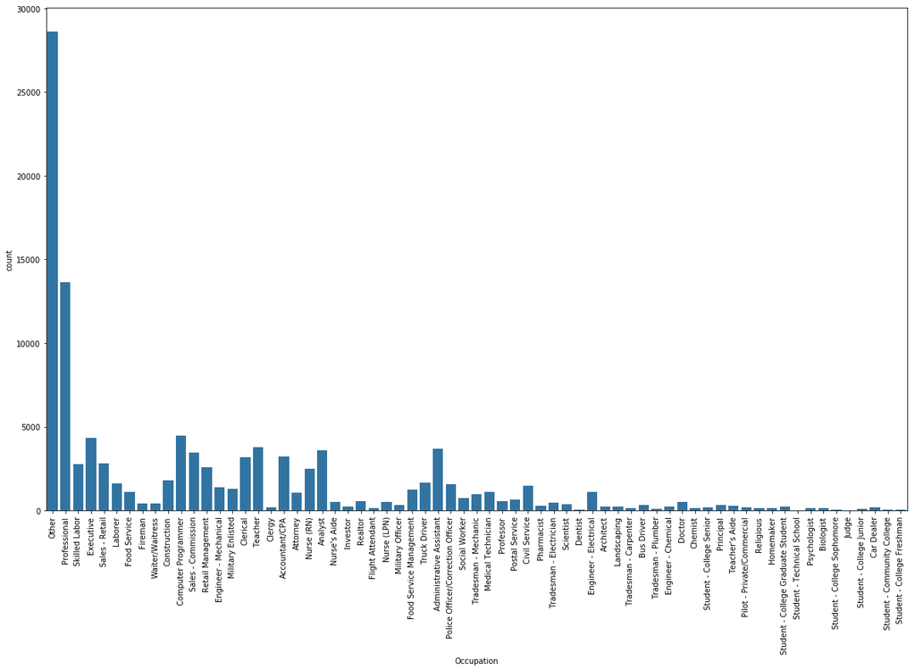

```python
# Bar chart for distribution of 'Occupation' feature
plt.figure(figsize=(20, 12))
sb.countplot(data=df, x='Occupation', color=default_color)
plt.xticks(rotation=90);
```

Applying logarithmic transformations to make for better visibility of all occupations.

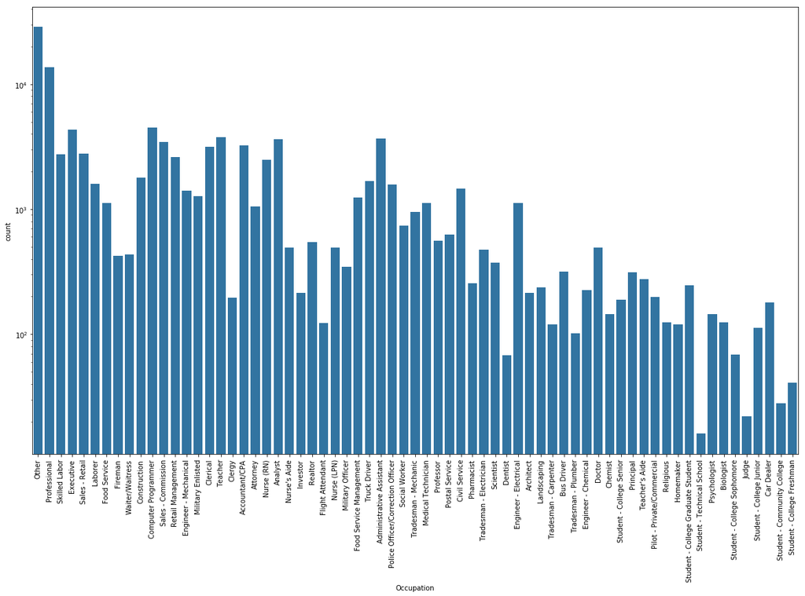

```python
# Bar chart for distribution of 'Occupation' feature after applying log transformation
plt.figure(figsize=(20, 12))
sb.countplot(data=df, x='Occupation', color=default_color)
plt.yscale('log')
plt.xticks(rotation=90);
```

We find that 'Other' and 'Professional' have the largest counts. To dig deeper into more specifics we remove 'Other' and 'Professional' from the dataset and plot again.

```python
subset_occupation = df[(df['Occupation'] != 'Other') & (df['Occupation'] != 'Professional')]['Occupation']
print('Other' in subset_occupation.unique())
print('Professional' in subset_occupation.unique())
```

```
False
False
```

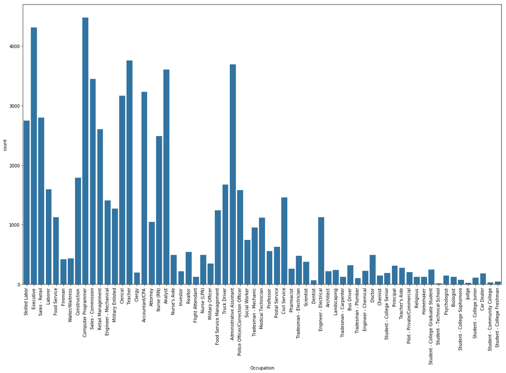

```python
# Bar chart for distribution of 'Occupation' feature after removing 'Other' and 'Professional' values
plt.figure(figsize=(20, 12))
sb.countplot(data=df, x=subset_occupation, color=default_color)
plt.xticks(rotation=90);
```

From the subset data obtained after removing 'Other' and 'Professional' from the feature 'Occupation', we find that the top 3 occupations granted loans by Prosper are 'Computer Programmer', 'Executive' and 'Teacher'.

## Bivariate Exploration

In this section, we will investigate relationships between pairs of variables in the data. We ensured that the variables covered here have been introduced in some fashion in the previous section (univariate exploration).

```python
df.head()
```

|  | ListingKey | ListingNumber | ListingCreationDate | CreditGrade | Term | LoanStatus | ClosedDate | BorrowerAPR | BorrowerRate | LenderYield | EstimatedEffectiveYield | EstimatedLoss | EstimatedReturn | ProsperRating (numeric) | ProsperRating (Alpha) | ProsperScore | ListingCategory | BorrowerState | Occupation | EmploymentStatus | EmploymentStatusDuration | IsBorrowerHomeowner | CurrentlyInGroup | GroupKey | DateCreditPulled | CreditScoreRangeLower | CreditScoreRangeUpper | FirstRecordedCreditLine | CurrentCreditLines | … |
| --- | --- | --- | --- | --- | --- | --- | --- | --- | --- | --- | --- | --- | --- | --- | --- | --- | --- | --- | --- | --- | --- | --- | --- | --- | --- | --- | --- | --- | --- | --- |
| 0 | 1021339766868145413AB3B | 193129 | 2007-08-26 19:09:29.263000000 | C | 36 | Completed | 2009-08-14 | 0.16516 | 0.1580 | 0.1380 | NaN | NaN | NaN | NaN | NaN | 0 | NotAvailable | CO | Other | Self-employed | 2.0 | True | True | NaN | 2007-08-26 18:41:46.780000000 | 640.0 | 659.0 | 2001-10-11 00:00:00 | 5.0 | … |
| 1 | 10273602499503308B223C1 | 1209647 | 2014-02-27 08:28:07.900000000 | NaN | 36 | Current | NaT | 0.12016 | 0.0920 | 0.0820 | 0.07960 | 0.0249 | 0.05470 | 6.0 | A | 7 | HomeImprovement | CO | Professional | Employed | 44.0 | False | False | NaN | 2014-02-27 08:28:14 | 680.0 | 699.0 | 1996-03-18 00:00:00 | 14.0 | … |
| 2 | 0EE9337825851032864889A | 81716 | 2007-01-05 15:00:47.090000000 | HR | 36 | Completed | 2009-12-17 | 0.28269 | 0.2750 | 0.2400 | NaN | NaN | NaN | NaN | NaN | 0 | NotAvailable | GA | Other | Not available | NaN | False | True | 783C3371218786870A73D20 | 2007-01-02 14:09:10.060000000 | 480.0 | 499.0 | 2002-07-27 00:00:00 | NaN | … |
| 3 | 0EF5356002482715299901A | 658116 | 2012-10-22 11:02:35.010000000 | NaN | 36 | Current | NaT | 0.12528 | 0.0974 | 0.0874 | 0.08490 | 0.0249 | 0.06000 | 6.0 | A | 9 | Motorcycle | GA | Skilled Labor | Employed | 113.0 | True | False | NaN | 2012-10-22 11:02:32 | 800.0 | 819.0 | 1983-02-28 00:00:00 | 5.0 | … |
| 4 | 0F023589499656230C5E3E2 | 909464 | 2013-09-14 18:38:39.097000000 | NaN | 36 | Current | NaT | 0.24614 | 0.2085 | 0.1985 | 0.18316 | 0.0925 | 0.09066 | 3.0 | D | 4 | HomeImprovement | MN | Executive | Employed | 44.0 | True | False | NaN | 2013-09-14 18:38:44 | 680.0 | 699.0 | 2004-02-20 00:00:00 | 19.0 | … |

### Explore the relationship between the features 'ProsperScore' (risk) and 'BorrowerRate'

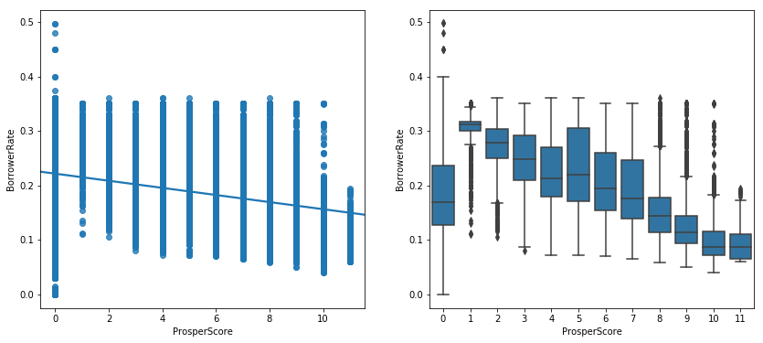

```python
plt.figure(figsize=(14, 6))

plt.subplot(1, 2, 1)
sb.regplot(data=df, x='ProsperScore', y='BorrowerRate')

plt.subplot(1, 2, 2)
sb.boxplot(data=df, x='ProsperScore', y='BorrowerRate', color=default_color);
```

From the left subplot we find that there is a negative linear relationship between the features 'ProsperScore' (i.e. risk) and 'BorrowerRate'. It shows that loans with high borrower rate are most common with smaller prosper score (i.e. higher risk values). This can also be validated from the right subplot where if we ignore the zero value (risk value) for 'Prosper Score' which signifies no score provided by Prosper, the median values starting from 'PropserScore' 1 to 10 emulate a negative relationship line.

### Explore the relationship between features 'ProsperRating (numeric)' and 'BorrowerRate'

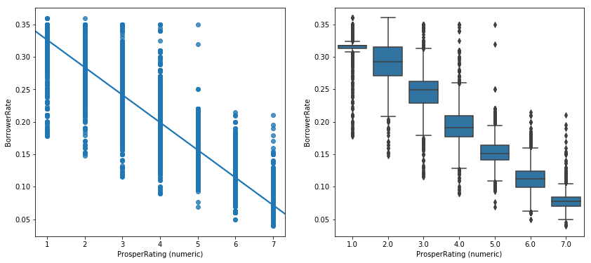

```python
plt.figure(figsize=(14, 6))

plt.subplot(1, 2, 1)
sb.regplot(data=df, x='ProsperRating (numeric)', y='BorrowerRate')

plt.subplot(1, 2, 2)
sb.boxplot(data=df, x='ProsperRating (numeric)', y='BorrowerRate', color=default_color);
```

Similar to the relationship between 'ProsperScore' and 'BorrowerRate', the relationship between 'ProsperRate (numeric)' and 'BorrowerRate' is a negative linear relationship.

### Explore the relationship between the features 'ProsperScore' and 'StatedMonthlyIncome'

```python
df['StatedMonthlyIncome'].dtype
```

```
dtype('float64')
```

```python
df['StatedMonthlyIncome'].describe()
```

```
count    1.139370e+05
mean     5.608026e+03
std      7.478497e+03
min      0.000000e+00
25%      3.200333e+03
50%      4.666667e+03
75%      6.825000e+03
max      1.750003e+06
Name: StatedMonthlyIncome, dtype: float64
```

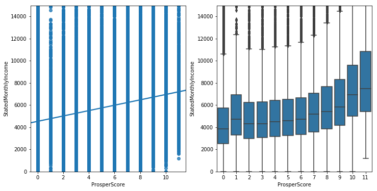

```python
plt.figure(figsize=(12, 6))

plt.subplot(1, 2, 1)
sb.regplot(data=df, x='ProsperScore', y='StatedMonthlyIncome')
plt.ylim((0, 15000));

plt.subplot(1, 2, 2)
sb.boxplot(data=df, x='ProsperScore', y='StatedMonthlyIncome', color=default_color)
plt.ylim((0, 15000));
```

We find from both the subplots that higher monthly income tend to be identified with higher prosper score (better risk profile), even though there are a few outliers where higher monthly incomes are categorized with low prosper score (high risk profile).

### Explore the relationship between the features 'AvailableBankcardCredit' and 'BorrowerRate'

```python
df['AvailableBankcardCredit'].describe()
```

```
count    106393.000000
mean      11210.225447
std       19818.361309
min           0.000000
25%         880.000000
50%        4100.000000
75%       13180.000000
max      646285.000000
Name: AvailableBankcardCredit, dtype: float64
```

```python
df['BorrowerRate'].describe()
```

```
count    113937.000000
mean          0.192764
std           0.074818
min           0.000000
25%           0.134000
50%           0.184000
75%           0.250000
max           0.497500
Name: BorrowerRate, dtype: float64
```

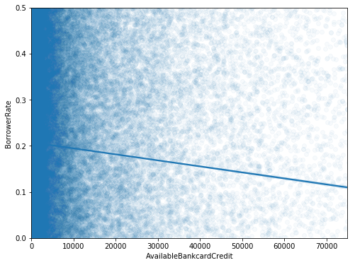

```python
plt.figure(figsize = [8, 6])
sb.regplot(data=df, x='AvailableBankcardCredit', y='BorrowerRate', \
           x_jitter = 0.5, y_jitter = 0.5, scatter_kws = {'alpha' : 1/30})
plt.xlim((0, 75000))
plt.ylim(0, 0.5);
```

The plot above shows a negative linear relationship such that higher values of 'AvailableBankcardCredit' lowers the 'BorrowerRate' values.

### Explore the relationship between the features 'LoanStatus' and 'ProsperRating (Alpha)'

```python
df['LoanStatus'].unique()
```

```
array(['Completed', 'Current', 'Past Due (1-15 days)', 'Defaulted',
       'Chargedoff', 'Past Due (16-30 days)', 'Cancelled',
       'Past Due (61-90 days)', 'Past Due (31-60 days)',
       'Past Due (91-120 days)', 'FinalPaymentInProgress',
       'Past Due (>120 days)'], dtype=object)
```

```python
# Create new feature 'CheckDefaultedLoan'
# 'CheckDefaultedLoan' has value 'True' for defaulted/chargedoff loans and value 'False' for completed loans
df['CheckDefaultedLoan'] = (df['LoanStatus'] == 'Defaulted') | (df['LoanStatus'] == 'Chargedoff')
```

```python
df['CheckDefaultedLoan'].unique()
```

```
array([False,  True])
```

```python
df[['LoanStatus', 'CheckDefaultedLoan']].head(20)
```

|  | LoanStatus | CheckDefaultedLoan |
| --- | --- | --- |
| 0 | Completed | False |
| 1 | Current | False |
| 2 | Completed | False |
| 3 | Current | False |
| 4 | Current | False |
| 5 | Current | False |
| 6 | Current | False |
| 7 | Current | False |
| 8 | Current | False |
| 9 | Current | False |
| 10 | Current | False |
| 11 | Completed | False |
| 12 | Past Due (1-15 days) | False |
| 13 | Current | False |
| 14 | Current | False |
| 15 | Defaulted | True |
| 16 | Current | False |
| 17 | Chargedoff | True |
| 18 | Current | False |
| 19 | Current | False |

```python
df[['LoanStatus', 'CheckDefaultedLoan']].tail(20)
```

|  | LoanStatus | CheckDefaultedLoan |
| --- | --- | --- |
| 113917 | Current | False |
| 113918 | Defaulted | True |
| 113919 | Current | False |
| 113920 | Current | False |
| 113921 | Completed | False |
| 113922 | Completed | False |
| 113923 | Completed | False |
| 113924 | Current | False |
| 113925 | Current | False |
| 113926 | Defaulted | True |
| 113927 | Completed | False |
| 113928 | Completed | False |
| 113929 | Completed | False |
| 113930 | Current | False |
| 113931 | Current | False |
| 113932 | Current | False |
| 113933 | FinalPaymentInProgress | False |
| 113934 | Current | False |
| 113935 | Completed | False |
| 113936 | Current | False |

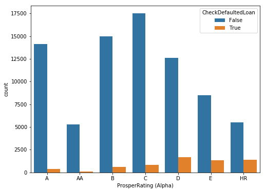

```python
plt.figure(figsize=(8, 6))
cat_order = ['A', 'AA', 'B', 'C', 'D', 'E', 'HR']
sb.countplot(data=df, x='ProsperRating (Alpha)', hue='CheckDefaultedLoan', order=cat_order);
```

We find that proportion of defaulted loans in the higher rating groups (i.e. 'ProsperRating (Alpha)) such as 'A' and 'AA' are lower in comparision to that in lower rating groups such as 'C', 'D', 'E' and 'HR'.

### Explore the relationship between the features 'LoanStatus' and 'EmploymentStatus'

```python
df['EmploymentStatus'].dtype
```

```
dtype('O')
```

```python
df['EmploymentStatus'].unique()
```

```
array(['Self-employed', 'Employed', 'Not available', 'Full-time', 'Other',
       nan, 'Not employed', 'Part-time', 'Retired'], dtype=object)
```

We will utilize the new feature 'CheckDefaultedLoan' (to represent the feature 'LoanStatus') which has value 'True' for defaulted/chargedoff loans and value 'False' for completed loans.

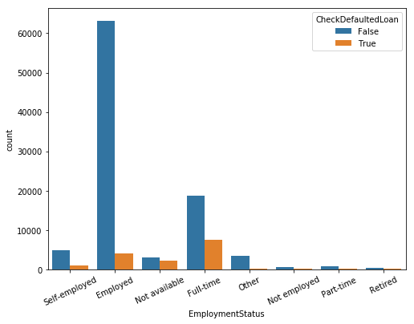

```python
plt.figure(figsize=(8, 6))
sb.countplot(data=df, x='EmploymentStatus', hue='CheckDefaultedLoan')
plt.xticks(rotation=25);
```

### Explore the relationship between features 'LoanStatus' and 'StatedMonthlyIncome'

```python
df['StatedMonthlyIncome'].dtype
```

```
dtype('float64')
```

```python
df['StatedMonthlyIncome'].describe()
```

```
count    1.139370e+05
mean     5.608026e+03
std      7.478497e+03
min      0.000000e+00
25%      3.200333e+03
50%      4.666667e+03
75%      6.825000e+03
max      1.750003e+06
Name: StatedMonthlyIncome, dtype: float64
```

We will utilize the new feature 'CheckDefaultedLoan' (to represent the feature 'LoanStatus') which has value 'True' for defaulted/chargedoff loans and value 'False' for completed loans.

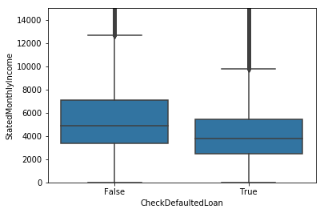

```python
sb.boxplot(data=df, x='CheckDefaultedLoan', y='StatedMonthlyIncome', color=default_color)
plt.ylim((0, 15000));
```

We can see from the above plot that the mean of 'MonthlyStatedIncome' for the group of borrowers who have completed their loans is higher than the mean of 'MonthlyStatedIncome' for the defaulting group. However, we find that this data contains a large number of outliers.

### Explore the relationship between features 'DebtToIncomeRatio' and 'BorrowerRate'

```python
df['BorrowerRate'].describe()
```

```
count    113937.000000
mean          0.192764
std           0.074818
min           0.000000
25%           0.134000
50%           0.184000
75%           0.250000
max           0.497500
Name: BorrowerRate, dtype: float64
```

```python
df['DebtToIncomeRatio'].describe()
```

```
count    105383.000000
mean          0.275947
std           0.551759
min           0.000000
25%           0.140000
50%           0.220000
75%           0.320000
max          10.010000
Name: DebtToIncomeRatio, dtype: float64
```

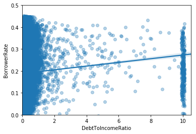

```python
sb.regplot(data=df, x='DebtToIncomeRatio', y='BorrowerRate', \
          x_jitter = 0.1, y_jitter = 0.1, scatter_kws = {'alpha' : 1/3})
plt.xlim(0, 10.5)
plt.ylim((0, 0.5));
```

We can see from the above plot that borrowers with higher 'DebtToIncomeRatio' (i.e. more debt relative to their income) will be asked for a higher 'BorrowerRate' for future loans by Prosper.

### Explore the relationship between features 'IsBorrowerHomeowner' and 'BorrowerRate'

```python
df['IsBorrowerHomeowner'].dtype
```

```
dtype('bool')
```

```python
df['IsBorrowerHomeowner'].unique()
```

```
array([ True, False])
```

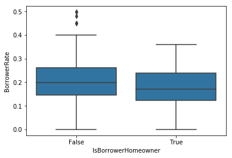

```python
sb.boxplot(data=df, x='IsBorrowerHomeowner', y='BorrowerRate', color=default_color);
```

We can see from the plot above that borrowers who are also home owners are charged a relatively less BorrowerRate than those who are not.

### Bivariate Analysis

#### Also included are cases of distributions with possible operations on the data to tidy, adjust, or change the form of the data

- There is a negative linear relationship between the features 'ProsperScore' (i.e. risk) and 'BorrowerRate'. It shows that loans with high borrower rate are most common with smaller Prosper score (i.e. higher risk values) and loans with relatively low borrower rare are most common with higher Prosper score.
  - Ignored the zero value (risk value) for 'Prosper Score' which signifies no score provided by Prosper.
- Similar to the relationship between 'ProsperScore' and 'BorrowerRate', the relationship between 'ProsperRate (numeric)' and 'BorrowerRate' is a negative linear relationship.
- Higher monthly income tend to be identified with higher prosper score (better risk profile), even though there are a few outliers where higher monthly incomes are categorized with low prosper score (high risk profile).
  - Handled the outliers by limting the values on y-axis represented by 'StatedMonthlyIncome' using the code as provided below:
    - `plt.ylim((0, 15000))`
- There is a negative linear relationship between 'AvailableBankcardCredit' and 'BorrowerRate' such that higher values of 'AvailableBankcardCredit' lowers the 'BorrowerRate' values and vice versa.
  - Handled the outliers by limiting the values on x-axis represented by 'AvailableBankcardCredit'. Also added jitter to the x and y values along with an alpha parameter as shown in the code below:

    - ```
      plt.figure(figsize = [8, 6])
       sb.regplot(data=df, x='AvailableBankcardCredit', y='BorrowerRate', \
       x_jitter = 0.5, y_jitter = 0.5, scatter_kws = {'alpha' : 1/30})
       plt.xlim((0, 75000))
       plt.ylim(0, 0.5);
      ```

    - ```
      sb.regplot(data=df, x='DebtToIncomeRatio', y='BorrowerRate', \
       x_jitter = 0.1, y_jitter = 0.1, scatter_kws = {'alpha' : 1/3})
       plt.xlim(0, 10.5)
       plt.ylim((0, 0.5));
      ```

- Borrowers who are also home owners are charged a relatively less borrower rate than those who are not.

### Some of the relationships observed in this part of the investigation. How did the feature(s) of interest vary with other features in the dataset?

- 'ProsperScore' and 'ProsperRating (numeric)' of the borrower have a marked effect in deciding the interest rate of their loans.
- 'AvailableBankcardCredit' is another significant feature in deciding the the interest rate for the borrower from Prosper.
- As the 'StatedMonthlyIncome' rises so does the 'ProsperScore' (or rating).
- Borrowers who have higher 'DebtToIncomeRatio' have higher rates of interests for future loans from Prosper and vice versa.
- Borrowers who are home owners tend to have relatively lower rates of interests from Prosper than those who are not.
- Median income of borrowers who completed their loans (or paid their loans completely) are relatively higher than median income of borrowers who defaulted on their loans.

## Multivariate Exploration

In this section we will create plots of three or more variables to investigate the data even further making sure that the investigations are justified, and follow from our work in the previous sections.

### Explore the the relationship between the features 'DebtToIncomeRatio', 'BorrowerRate' and 'ProsperRating (numeric)'

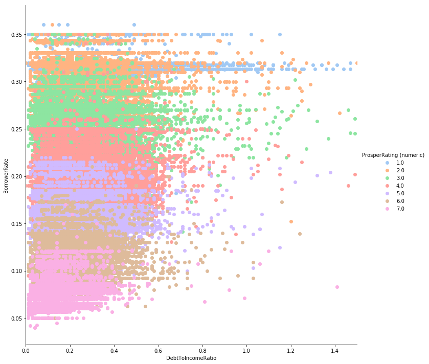

```python
g = sb.FacetGrid(data=df, hue='ProsperRating (numeric)', size=10, palette='pastel')
g.map(plt.scatter, 'DebtToIncomeRatio', 'BorrowerRate')
plt.xlim((0, 1.5))
g.add_legend();
```

- As the 'ProsperRating (numeric)' move from lower to higher values of 1 to 7, 'DebtToIncomeRatio' as well as 'BorrowerRate' decreases.
- Higher 'DebtToIncomeRatio' and 'BorrwerRate' are associated with lower 'ProsperRating (numeric)'.
- Lower 'DebtToIncomeRatio' and 'BorrwerRate' are key indicators for a higher Prosper rating i.e. 'ProsperRating (numeric)'.

### Explore the the relationship between the features 'StatedMonthlyIncome', 'DebtToIncomeRatio' and 'LoanStatus'

Created a new variable 'CheckDefaultedLoan' to group the 'LoanStatus' feature into two groups which has value 'True' for defaulted/chargedoff loans and value 'False' for completed loans.

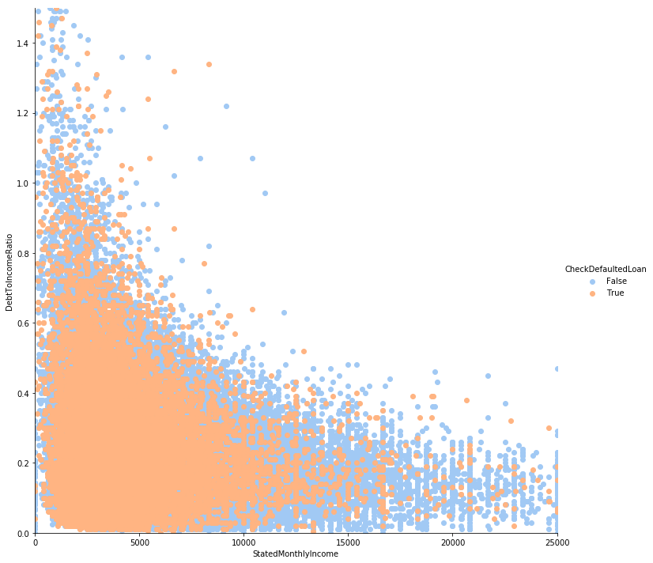

```python
g = sb.FacetGrid(data=df, hue='CheckDefaultedLoan', size=10, palette='pastel')
g.map(plt.scatter, 'StatedMonthlyIncome', 'DebtToIncomeRatio')
plt.xlim((0, 25000))
plt.ylim((0, 1.5))
g.add_legend();
```

- Low values of 'StatedMonthlyIncome' result in defaulted loans irrespective of the fact whether 'DebtToIncome' ratios are low or high.
- High values of 'StatedMonthlyIncome' result in lesser defaulted loans irrespective of the fact whether 'DebtToIncome' ratios are low or high.
- Hence 'StatedMonthlyIncome' is a pretty good indicator of safe loans by Prosper.

### Explore the the relationship between the features 'StatedMonthlyIncome', 'LoanOriginalAmount' and 'LoanStatus'.

Created a new variable 'CheckDefaultedLoan' to group the 'LoanStatus' feature into two groups which has value 'True' for defaulted/chargedoff loans and value 'False' for completed loans.

```python
df['LoanOriginalAmount'].describe()
```

```
count    113937.00000
mean       8337.01385
std        6245.80058
min        1000.00000
25%        4000.00000
50%        6500.00000
75%       12000.00000
max       35000.00000
Name: LoanOriginalAmount, dtype: float64
```

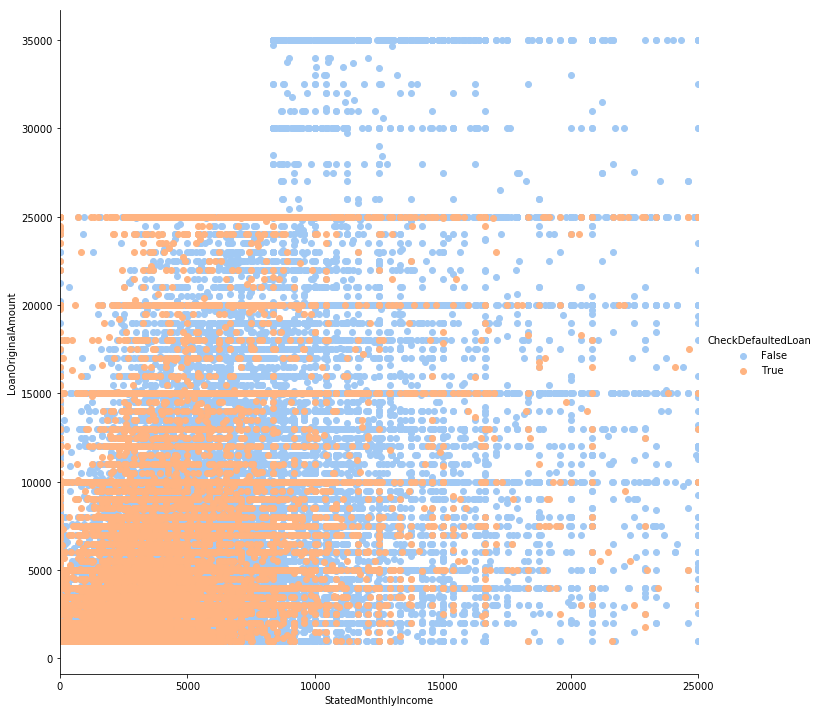

```python
g = sb.FacetGrid(data=df, hue='CheckDefaultedLoan', size=10, palette='pastel')
g.map(plt.scatter, 'StatedMonthlyIncome', 'LoanOriginalAmount')
plt.xlim((0, 25000))
g.add_legend();
```

- Low values of 'StatedMonthlyIncome' result in defaulted loans irrespective of low or high values of 'LoanOriginalAmount'.
- High values of 'StatedMonthlyIncome' result in lesser defaulted loans irrespective of the fact whether 'LoanOriginalAmount' values are low or high.
- Once again we find that 'StatedMonthlyIncome' is a pretty good indicator of safe loans by Prosper.

### Explore the the relationship between the features 'IncomeRange', 'BorrowerRate' and 'LoanStatus'.

```python
df['IncomeRange'].dtype
```

```
dtype('O')
```

```python
df['IncomeRange'].unique()
```

```
array(['$25,000-49,999', '$50,000-74,999', 'Not displayed', '$100,000+',
       '$75,000-99,999', '$1-24,999', 'Not employed', '$0'], dtype=object)
```

```python
income_range_order = ['$0', 'Not employed', '$1-24,999', '$25,000-49,999', '$50,000-74,999', '$75,000-99,999', '$100,000+', 'Not displayed']
ordered_cat = pd.api.types.CategoricalDtype(ordered=True, categories=income_range_order)
df['IncomeRange'] = df['IncomeRange'].astype(ordered_cat)
```

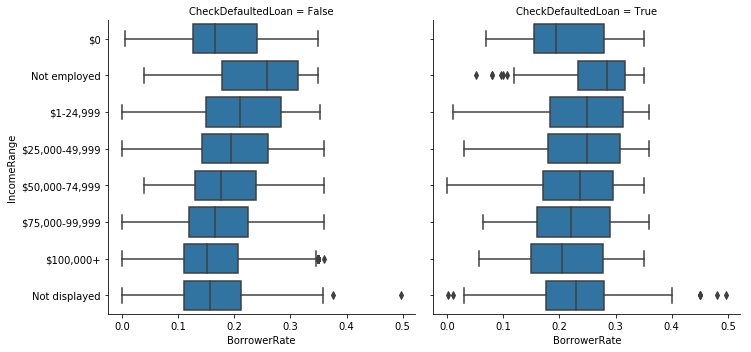

```python
g = sb.FacetGrid(data=df, col='CheckDefaultedLoan', size=5, col_wrap=3)
g.map(sb.boxplot, 'BorrowerRate', 'IncomeRange');
```

We find from the above plot that as the borrower moves from lower to higher income ranges, Prosper decreases the 'BorrowerRate' making it an important player in the lending market.